[figure not shown]

# Uniform-like Sampling of Superellipsoid Surface

Superellipsoids are a mathematical concept commonly used for modeling and completing shapes in 3D point clouds. In this post, we will demonstrate how to uniformly sample the surface of a superellipsoid in the Cartesian coordinate system.

Published on April 23, 2022

# Table of Contents

We needed to uniform(-like) sampling of a superellipsoid's surface for our capsicum_superellipsoid_detector project. In this project, superellipsoids are matched to scanned pointclouds and this idea is used to find missing (not scanned) surfaces of Capsicum fruits, which will be important for robot arm planner.

In this post, the firstly discuss a method for sampling using the parametric representation of superellipsoid. This method has problems with sampling surfaces uniformly which prevents us from using it in our project. Secondly, it is known that fibonacci sphere is a famous method for uniformly sampling a sphere surface. Our solution consists of projecting a fibonacci sphere onto a superellipsoid by using an approximated distance function.

**NOTE:** Please refrain from using functions named with a underscore postfix (*_) since they are not optimized. Optimized functions are given at the end of this post.

## Parametric Representation

The implicit equation of a Superellipsoid being

$$ f(\theta, x, y, z) = \left( \left | \frac{x}{A} \right | ^\frac{2}{e_2} + \left | \frac{y}{B} \right | ^\frac{2}{e_2} \right )^\frac{e_2}{e_1} + \left | \frac{z}{C} \right | ^\frac{2}{e_1} = 1 $$

where $\theta$ are superellipsoid parameters ($A$, $B$, $C$, $e_1$, $e_2$). The general superellipsoid has a parametric representation in terms of surface parameters $-\frac{\pi}{2} < v < \frac{\pi}{2}$, $-\pi < u < \pi$.

$$ x(u,v) = A c \left(v,e_1 \right) c \left(u,e_2 \right) $$

$$ y(u,v) = B c \left(v,e_1 \right) s \left(u,e_2 \right) $$

$$ z(u,v) = C s \left(v,e_1 \right) $$

where the auxiliary functions are

$$ c(w,m) = \text{sgn}(\cos w) | \cos w |^m $$

$$ s(w,m) = \text{sgn}(\sin w) | \sin w |^m $$

where $\text{sgn}(x)$ is the [sign function](https://numpy.org/doc/stable/reference/generated/numpy.sign.html). See the [wikipedia page](https://en.wikipedia.org/wiki/Superellipsoid) for more information. Note that Wikipedia uses a bit different notation which are $r=\frac{2}{e_2}$ and $t=\frac{2}{e_1}$.

```python
import numpy as np
import matplotlib.pyplot as plt
from mpl_toolkits.mplot3d import Axes3D
```

```python
def c_func(w,m): return np.sign(np.cos(w)) * np.abs(np.cos(w))**m
def s_func(w,m): return np.sign(np.sin(w)) * np.abs(np.sin(w))**m

def sample_superellipsoid_parametric(A=1, B=1, C=1, e1=0.5, e2=0.3, u_num_samples=50, v_num_samples=50):
    v = np.linspace(-np.pi/2, np.pi/2, v_num_samples)
    u = np.linspace(-np.pi, np.pi, u_num_samples)
    uu, vv = np.meshgrid(u, v)
    x = A * c_func(vv, e1) * c_func(uu, e2)
    y = B * c_func(vv, e1) * s_func(uu, e2)
    z = C * s_func(vv, e1)
    return np.array([x, y, z]).reshape((3,-1)).T
```

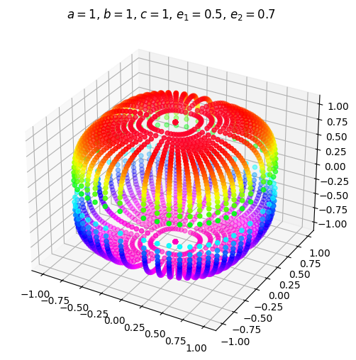

```python
a,b,c,e1,e2 = 1, 1, 1, 0.5, 0.7
points = sample_superellipsoid_parametric(a,b,c,e1,e2)

fig = plt.figure(figsize=(6,6))
ax = fig.add_subplot(projection='3d')
ax.set_title("$a={}$, $b={}$, $c={}$, $e_1={}$, $e_2={}$".format(a,b,c,e1,e2))
_=ax.scatter(points[:,0], points[:,1], points[:,2], c=-points[:,2], cmap="gist_rainbow")
```

## The Problem of Sampling with Parametric Representation

Well...

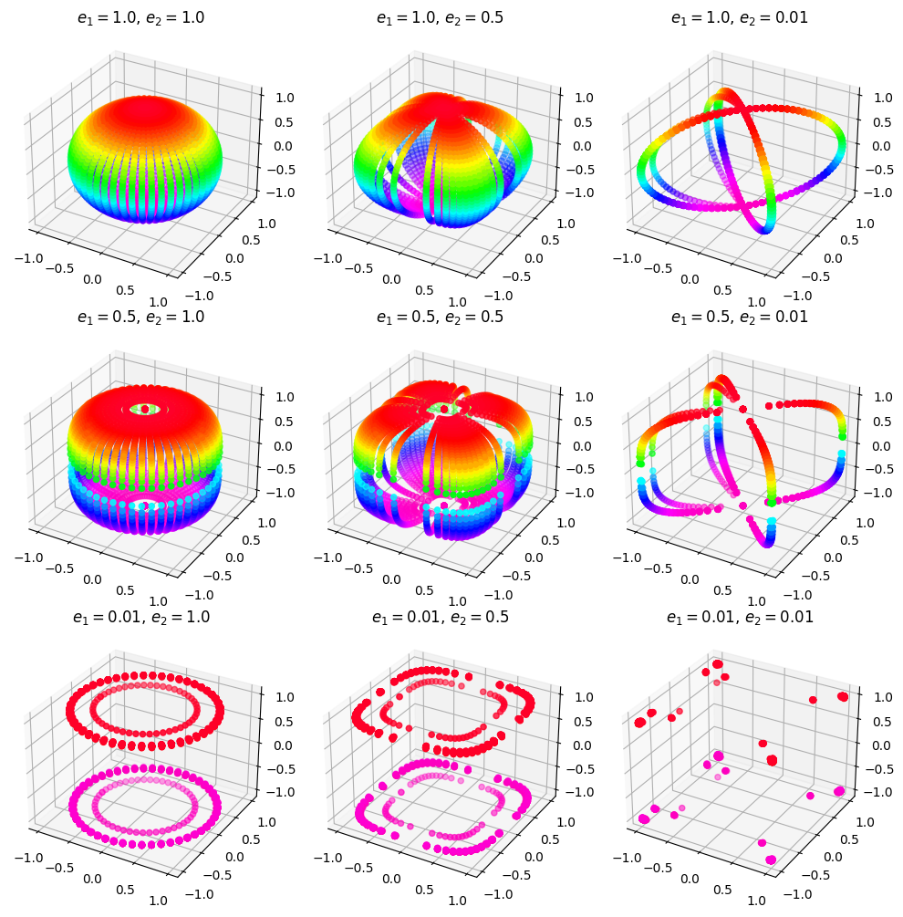

```python
fig = plt.figure(figsize=(10,10))
e_values = [1.0, 0.5, 0.01]
for i,e1 in enumerate(e_values):
    for j,e2 in enumerate(e_values):
        ax = fig.add_subplot(len(e_values), len(e_values), i*len(e_values)+j+1, projection='3d')
        points = sample_superellipsoid_parametric(1,1,1,e1,e2)
        ax.set_title("$e_1={}$, $e_2={}$".format(e1,e2))
        _=ax.scatter(points[:,0], points[:,1], points[:, 2], c=-points[:,2], cmap="gist_rainbow")
fig.tight_layout()
```

[figure not shown]

## Solution: Projecting Fibonacci Sphere onto Superellipsoid

### Fibonacci Sphere

Fibonacci sphere is a pretty way for uniform-like sampling sphere surfaces. I have used the code shared here: https://stackoverflow.com/a/26127012

```python
# see: https://stackoverflow.com/a/26127012
# Optimized version of this code is provided at the end of this post!
def sample_fibonacci_sphere_(samples):
    points = np.zeros((samples, 3))
    phi = np.pi * (3 - np.sqrt(5))  # golden angle in radians

    for i in range(samples):
        y = 1 - (i / (samples - 1)) * 2   # y goes from 1 to -1
        radius = np.sqrt(1 - y * y)  # radius at y
        theta = phi * i  # golden angle increment
        x = np.cos(theta) * radius
        z = np.sin(theta) * radius
        points[i] = [x, y, z]

    return points
```

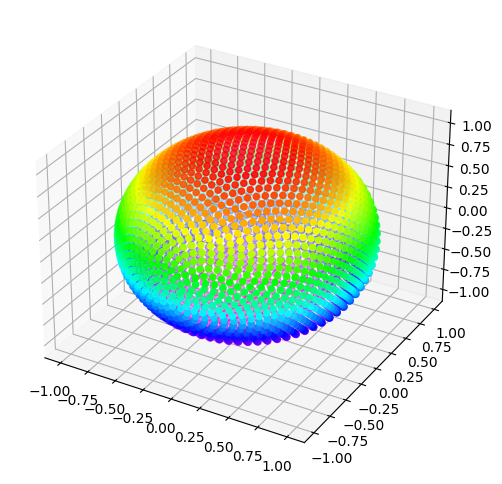

```python
points = sample_fibonacci_sphere_(samples=2500)
fig = plt.figure(figsize=(6,6))
ax = fig.add_subplot(111, projection='3d')
_=ax.scatter(points[:,0], points[:,1], points[:, 2], c=-points[:,2], cmap="gist_rainbow")
```

### Solina's Method

Solina proposed this approximation for the distance;

$$ d(\theta, x, y, z) = f(\theta, x, y, z)^\frac{e_1}{2} - 1 $$

where $\theta$ are superellipsoid parameters and $f$ is the implicit equation of superellipsoid (both are presented in **Parametric Representation** section). Also, I have observed that Solina's approximation distance works pretty well when $A=B=C=1$, empirically. See the reference for comparison of approximated distance functions for superellipsoids.

**Reference:** Chevalier, Laurent, Fabrice Jaillet, and Atilla Baskurt. "Segmentation and superquadric modeling of 3D objects." (2003). ([PDF](https://otik.uk.zcu.cz/bitstream/11025/1637/1/D71.pdf))

```python
# use Solina's method but assume that a=b=c=1
def compute_superellipsoid_distance(x, y, z, e1, e2):
    f = ((np.abs(x))**(2/e2) + (np.abs(y))**(2/e2) )**(e2/e1) + (np.abs(z))**(2/e1)
    d = np.abs(1 - f**(e1/2))
    return np.where(f>1, d, -d) # use sign to find if the point is inside or outside
```

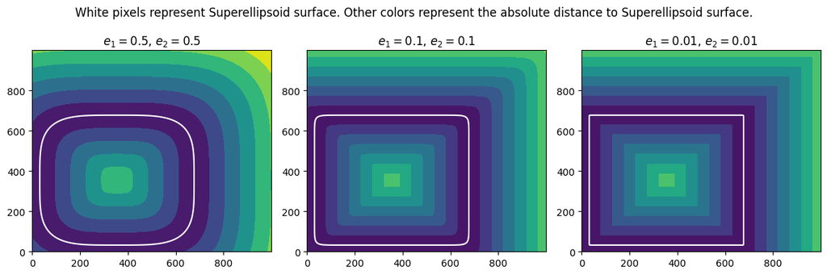

```python
x = np.linspace(-1.1, 2, 1000)
y = np.linspace(-1.1, 2, 1000)
xx, yy = np.meshgrid(x, y)
zz = 0.0
e_values = [(0.5, 0.5), (0.1, 0.1), (0.01, 0.01)]

fig, axs = plt.subplots(1, len(e_values), figsize=(12,4))
for i, (e1,e2) in enumerate(e_values):
    d = compute_superellipsoid_distance(xx, yy, zz, e1, e2)
    axs[i].contourf(np.abs(d), vmin=0, vmax=1.37) # vmax is found via print(d.min(), d.max())
    axs[i].contour(d, levels=[0], colors="white")
    axs[i].set_title("$e_1={}$, $e_2={}$".format(e1,e2))
fig.suptitle("White pixels represent Superellipsoid surface. Other colors represent the absolute distance to Superellipsoid surface.")
fig.tight_layout()
```

### Project Points onto Superellipsoid

$$ d_{i+1} = d_i \left ( \frac{ || d_i || - \text{solina}(d_i) }{||d_i||} \right ) $$

```python
# Optimized version of this code is provided at the end of this post! Don't use this function!
def sample_superellipsoid_fibonacci_(a, b, c, e1, e2, num_samples=2500, limit_e1_e2=True):
    if limit_e1_e2:
        e1 = np.clip(e1, 0.01, 1.0)
        e2 = np.clip(e2, 0.01, 1.0)

    points = sample_fibonacci_sphere_(num_samples)
    for i in range(10): # for the given e1/e2 values 10 iterations are enough
        d = compute_superellipsoid_distance(points[:,0],points[:,1],points[:,2],e1,e2)
        m = np.sum(points**2, axis=1)**0.5 # dist from center
        points = points * ((m-d)/m).reshape(-1,1)
    points *= np.array([a,b,c])
    return points
```

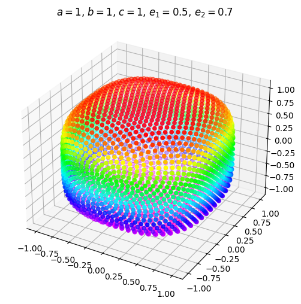

```python
a,b,c,e1,e2 = 1, 1, 1, 0.5, 0.7
points = sample_superellipsoid_fibonacci_(a,b,c,e1,e2)

fig = plt.figure(figsize=(6,6))
ax = fig.add_subplot(111, projection='3d')
ax.set_title("$a={}$, $b={}$, $c={}$, $e_1={}$, $e_2={}$".format(a,b,c,e1,e2))
_=ax.scatter(points[:,0], points[:,1], points[:, 2], c=-points[:,2], cmap="gist_rainbow")
```

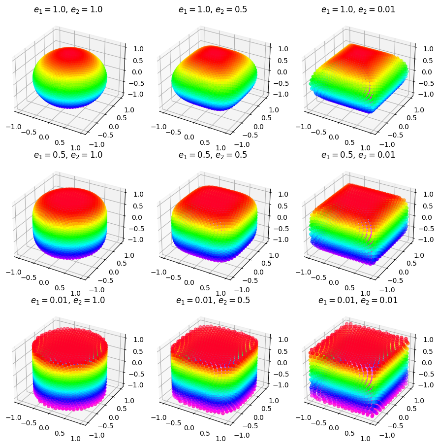

```python
fig = plt.figure(figsize=(9,9))
e_values = [1.0, 0.5, 0.01]
for i,e1 in enumerate(e_values):
    for j,e2 in enumerate(e_values):
        ax = fig.add_subplot(len(e_values), len(e_values), i*len(e_values)+j+1, projection='3d')
        points = sample_superellipsoid_fibonacci_(1,1,1,e1,e2)
        ax.set_title("$e_1={}$, $e_2={}$".format(e1,e2))
        _=ax.scatter(points[:,0], points[:,1], points[:, 2], c=-points[:,2], cmap="gist_rainbow")
fig.tight_layout()
```

### Finding a Good Value for Maximum Number of Iterations

More iterations can be set for more accurate results. For our project 10 iterations seems well enough.

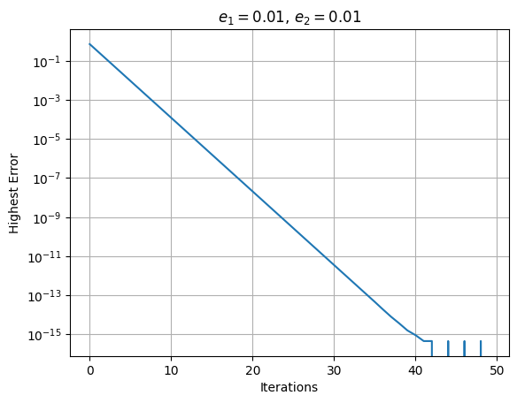

```python
def sample_superellipsoid_debug_(a, b, c, e1, e2, num_samples=100000, max_iter = 50):
    points = sample_fibonacci_sphere_(num_samples)
    d_ = []
    for i in range(max_iter):
        d = compute_superellipsoid_distance(points[:,0],points[:,1],points[:,2],e1,e2)
        m = np.sum(points**2, axis=1)**0.5
        d_.append(m)
        points = points * ((m-d)/m).reshape(-1,1)
    points *= np.array([a,b,c])
    return points, np.array(d_)

e1,e2 = 0.01, 0.01
points, d = sample_superellipsoid_debug_(1,1,1,e1,e2)
groundtruth = d[-1].reshape(1,-1)
dd = np.max(np.abs(d-groundtruth), axis=1)
plt.xlabel("Iterations")
plt.ylabel("Highest Error")
plt.title("$e_1={}$, $e_2={}$".format(e1,e2))
plt.yscale("log")
plt.grid()
_=plt.plot(dd)
```

## Optimized Code: Fibonacci Sphere Sampling

```python
# Optimized version of https://stackoverflow.com/a/26127012
def sample_fibonacci_sphere(samples):
    phi = np.pi * (3 - np.sqrt(5))  # golden angle in radians
    i = np.arange(samples)
    y = 1 - (i / (samples - 1)) * 2   # y goes from 1 to -1
    radius = np.sqrt(1 - y * y)  # radius at y
    theta = phi * i  # golden angle increment
    x = np.cos(theta) * radius
    z = np.sin(theta) * radius
    return np.array([x, y, z]).T
```

### Benchmark

```python
print("Old fibonacci sphere sampling timings:")
%timeit sample_fibonacci_sphere_(1000)

print("\nOptimized fibonacci sphere sampling timings:")
%timeit sample_fibonacci_sphere(1000)
```

```
Old fibonacci sphere sampling timings:
2.85 ms ± 14 µs per loop (mean ± std. dev. of 7 runs, 100 loops each)

Optimized fibonacci sphere sampling timings:
41.9 µs ± 338 ns per loop (mean ± std. dev. of 7 runs, 10,000 loops each)
```

## Optimized Code: Superellipsoid Sampling

**!!! BETTER VERSION OF THIS FUNCTION IS AVAILABLE BELOW !!!**

This function combines fibonacci sphere sampling, superellipsoid distance function and projection of points into one. Firstly, optimized fibonacci sphere sampling is used in the first part. Secondly, `np.where` is replaced with `np.sign`, and `np.linalg.norm` is used instead of computing the norm with power functions. All of these optimizations improved total running time by ~4x.

Also I would like to note that, I have tried caching fibonacci sphere samples to optimize consecutive calls but the time taken for computation is increased in this way. I think this happens because sampling of fibonacci sphere is way faster than reading from memory. So I gave up on this idea. Furthermore, I have tried copying fibonacci sphere for using as a normalized points array. But this increase the running time a bit. I think it was a burden for CPU cache.

```python
def sample_superellipsoid_fibonacci(a, b, c, e1, e2, num_samples=2500, max_iter=10, limit_e1_e2=True):
    if limit_e1_e2:
        e1 = np.clip(e1, 0.01, 1.0)
        e2 = np.clip(e2, 0.01, 1.0)

    phi = np.pi * (3 - np.sqrt(5))        # golden angle in radians
    i = np.arange(num_samples)
    y = 1 - (i / (num_samples - 1)) * 2   # y goes from 1 to -1
    radius = np.sqrt(1 - y * y)           # radius at y
    theta = phi * i                       # golden angle increment
    x = np.cos(theta) * radius
    z = np.sin(theta) * radius
    s = np.array([x, y, z]).T

    for i in range(max_iter):
        f = (np.abs(s[:,0])**(2./e2) + np.abs(s[:,1])**(2./e2) )**(e2/e1) + np.abs(s[:,2])**(2./e1)
        d = np.sign(f-1) * np.abs(1 - f**(e1/2))
        m = np.linalg.norm(s, axis=1)
        s = s * (1-d/m).reshape(-1,1)

    return s * np.array([a,b,c])
```

### Benchmark

```python
print("Old superellipsoid sampling timings:")
%timeit sample_superellipsoid_fibonacci_(1,1,1,0.5,0.4,1000)

print("\nOptimized superellipsoid sampling timings:")
%timeit sample_superellipsoid_fibonacci(1,1,1,0.5,0.4,1000)
```

```
Old superellipsoid sampling timings:
4.27 ms ± 65.1 µs per loop (mean ± std. dev. of 7 runs, 100 loops each)

Optimized superellipsoid sampling timings:
1.14 ms ± 3.92 µs per loop (mean ± std. dev. of 7 runs, 1,000 loops each)
```

## UPDATE v2: Faster and Better!

$$ d_{i+1} = d_i \left (1 - \frac{ \text{solina}(d_i) }{||d_i||} \left( ||d_i||-\text{solina}(d_i) \right ) \right ) $$

```python
def sample_superellipsoid_fibonacci_v2(a, b, c, e1, e2, num_samples=2500, max_iter=6, limit_e1_e2=True):
    if limit_e1_e2:
        e1 = np.clip(e1, 0.01, 1.0)
        e2 = np.clip(e2, 0.01, 1.0)

    phi = np.pi * (3 - np.sqrt(5))        # golden angle in radians
    i = np.arange(num_samples)
    y = 1 - (i / (num_samples - 1)) * 2   # y goes from 1 to -1
    radius = np.sqrt(1 - y * y)           # radius at y
    theta = phi * i                       # golden angle increment
    x = np.cos(theta) * radius
    z = np.sin(theta) * radius
    s = np.array([x, y, z]).T

    for i in range(max_iter):
        f = (np.abs(s[:,0])**(2./e2) + np.abs(s[:,1])**(2./e2) )**(e2/e1) + np.abs(s[:,2])**(2./e1)
        d = np.sign(f-1) * np.abs(1 - f**(e1/2))
        m = np.linalg.norm(s, axis=1)
        s *= (1-(d/m)*(m-d)).reshape(-1,1)

    return s * np.array([a,b,c])
```

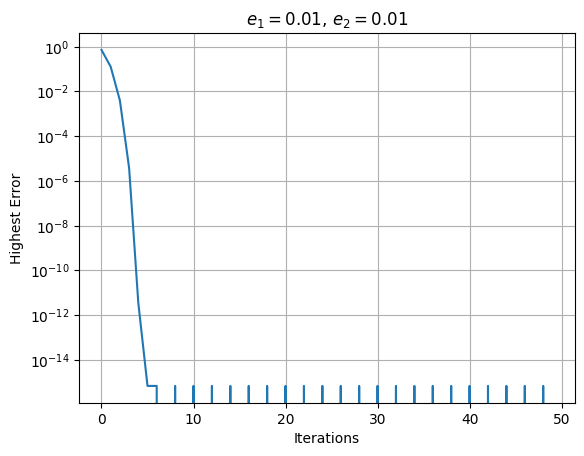

```python
def sample_superellipsoid_v2_debug_(a, b, c, e1, e2, num_samples=100000, max_iter = 50):
    points = sample_fibonacci_sphere_(num_samples)
    d_ = []
    for i in range(max_iter):
        d = compute_superellipsoid_distance(points[:,0],points[:,1],points[:,2],e1,e2)
        m = np.sum(points**2, axis=1)**0.5
        d_.append(m)
        points = points * (1-(d/m)*(m-d)).reshape(-1,1)
    points *= np.array([a,b,c])
    return points, np.array(d_)

e1,e2 = 0.01, 0.01
points, d = sample_superellipsoid_v2_debug_(1,1,1,e1,e2)
groundtruth = d[-1].reshape(1,-1)
dd = np.max(np.abs(d-groundtruth), axis=1)
plt.xlabel("Iterations")
plt.ylabel("Highest Error")
plt.title("$e_1={}$, $e_2={}$".format(e1,e2))
plt.yscale("log")
plt.grid()
_=plt.plot(dd)
```

```python
print("\nOptimized superellipsoid sampling v2 timings:")
%timeit sample_superellipsoid_fibonacci_v2(1,1,1,0.5,0.4,1000)
```

```
Optimized superellipsoid sampling v2 timings:
746 µs ± 12.5 µs per loop (mean ± std. dev. of 7 runs, 1,000 loops each)
```

## Animated Examples

```python
from matplotlib.animation import FuncAnimation
from IPython.display import HTML
from scipy import interpolate
```

### Fibonacci Sphere

```python
def animate(f):
    fig = plt.figure(figsize=(6,6))
    ax = fig.add_subplot(111, projection='3d')

    def update(frame):
        ax.clear()
        f(fig, ax, frame)
        ax.view_init(frame*15+20, frame*60)
        return

    ani = FuncAnimation(fig, update, frames=np.linspace(0, 1.0, 180), init_func=None, blit=False, interval=66)
    plt.close()
    return ani.to_html5_video()

def f(fig, ax, frame):
    n = int(frame*720)
    points = sample_fibonacci_sphere(n)
    ax.set_title("$n={}$".format(n))
    ax.scatter(points[:,0], points[:,1], points[:, 2], c=-points[:,2], cmap="gist_rainbow")

HTML(animate(f))
```

[video not shown]

### Superellipsoid

```python
def animate(f):
    fig = plt.figure(figsize=(6,6))
    ax = fig.add_subplot(111, projection='3d')

    def update(frame):
        ax.clear()
        f(fig, ax, frame)
        ax.view_init(frame*15+20, frame*60)
        return

    ani = FuncAnimation(fig, update, frames=np.linspace(0, 1.0, 180), init_func=None, blit=False, interval=66)
    plt.close()
    return ani.to_html5_video()

def f(fig, ax, frame):
    e1_    = [1.0, 0.5, 0.01, 0.5, 0.01, 1.0]
    e2_    = [1.0, 0.01, 1.0, 0.5, 0.01, 0.5]
    fe1 = interpolate.interp1d(np.linspace(0, 1.0, len(e1_)), e1_)
    fe2 = interpolate.interp1d(np.linspace(0, 1.0, len(e2_)), e2_)
    e1 = fe1(frame)
    e2 = fe2(frame)
    points = sample_superellipsoid_fibonacci_v2(a, b, c, e1, e2, 5000)
    ax.set_title("$e_1={}$, $e_2={}$".format(np.round(e1,2),np.round(e2,2)))
    ax.scatter(points[:,0], points[:,1], points[:, 2], c=-points[:,2], cmap="gist_rainbow")

HTML(animate(f))
```

[video not shown]

## Final Thoughts

I think some things would be better:

- Faster projection onto a Superellipsoid. Optimizing for $\text{~}40$ iterations to obtain perfect results is a bit too much.
- Uniform-like sampling for the cases where $A$, $B$, $C$ values are not close to each other.

What works well:

- Projected points look uniformly-like sampled.
- Computation is fast!
- Works pretty well with [our project](https://github.com/salihmarangoz/capsicum_superellipsoid_detector) for estimating missing surfaces (as shown in the image below).

[figure not shown]